# ARIMA Modeling and Forecasting of the French Dairy Production Index

Author

Varnel TIENTCHEU & Rivalien MAGUETSWET

Published

April 14, 2026

This project focuses on the econometric modeling and forecasting of a French economic time series. Using the Box-Jenkins methodology, we aim to identify, estimate, and validate an optimal model to predict future values of industrial output.

## Part I: The Data

### a) Data description

**Sector and Definition**

The series selected for this study is the **Industrial Production Index (IPI)** for the **Manufacture of Dairy Products** (NAF rev. 2, group 10.5) in France. This index, identified by Insee ID **010767631**, tracks the monthly volume of output for the dairy transformation industry.

**Time Span and Observations**

- **Period:** The dataset covers the period from **January 1990 to February 2026**.
- **Frequency:** Monthly.
- **Sample Size:** With 434 observations.

The series is obtained from the Insee time series databank and has undergone specific pre-processing:

- **CVS-CJO (SA-WDA):** The data is corrected for **seasonal variations** and **working day effects**. This is critical as it removes deterministic seasonal patterns (like the spring “milk flush”) and calendar-related noise, allowing us to focus on the underlying stochastic process.
- **Logarithmic Transformation:** We apply a natural log transformation ($ln(X_t)$) to the raw data. This is justified by the need to:
  1. **Stabilize Variance:** as the magnitude of fluctuations in industrial production often grows proportionally with the level of the index.
  2. **Linearize the Model:** Prepare the data for linear $ARIMA$ modeling where additive relationships are assumed.

  ```
  ──────────────────────────────────────────────────────── Delimiter: ";" chr
  (2): Période, ...3 dbl (1): ...2
  ```

  ```
  tibble [434 × 3] (S3: tbl_df/tbl/data.frame)
   $ t     : Date[1:434], format: "1990-01-01" "1990-02-01" ...
   $ Xt    : num [1:434] 81.9 83.2 85.3 86 86.5 ...
   $ status: chr [1:434] "A" "A" "A" "A" ...
  ```

### b) Stationnarity

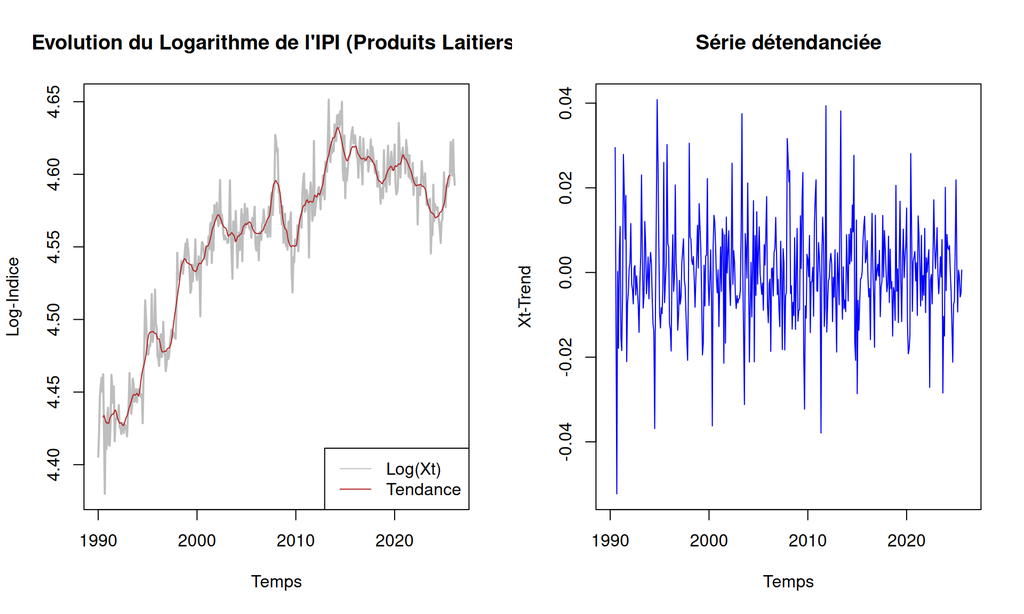

#### ADF test

To rigorously assess the stationarity of the $ln(X_t)$ series, we follow a sequential testing procedure. We initially consider the most general specification, which includes both a linear deterministic trend and an intercept (the “trend” model):

$$\Delta y_t = \alpha + \beta t + \gamma y_{t-1} + \sum_{i=1}^p \delta_i \Delta y_{t-i} + \varepsilon_t$$

```
###############################################
# Augmented Dickey-Fuller Test Unit Root Test #
###############################################

Test regression trend


Call:
lm(formula = z.diff ~ z.lag.1 + 1 + tt + z.diff.lag)

Residuals:
      Min        1Q    Median        3Q       Max
-0.040863 -0.007756 -0.000880  0.007681  0.044872

Coefficients:
              Estimate Std. Error t value Pr(>|t|)
(Intercept)  2.487e-01  9.933e-02   2.504 0.012655 *
z.lag.1     -5.518e-02  2.221e-02  -2.485 0.013363 *
tt           1.567e-05  1.010e-05   1.552 0.121328
z.diff.lag1 -4.140e-01  5.023e-02  -8.241 2.26e-15 ***
z.diff.lag2 -2.846e-01  5.158e-02  -5.518 6.05e-08 ***
z.diff.lag3 -1.689e-01  4.837e-02  -3.492 0.000532 ***
---
Signif. codes:  0 '***' 0.001 '**' 0.01 '*' 0.05 '.' 0.1 ' ' 1

Residual standard error: 0.0137 on 415 degrees of freedom
Multiple R-squared:  0.1993,    Adjusted R-squared:  0.1896
F-statistic: 20.66 on 5 and 415 DF,  p-value: < 2.2e-16


Value of test-statistic is: -2.4846 2.8189 3.5602

Critical values for test statistics:
      1pct  5pct 10pct
tau3 -3.98 -3.42 -3.13
phi2  6.15  4.71  4.05
phi3  8.34  6.30  5.36
```

Where $y_t = ln(X_t)$. The results for this specification show that the test statistic for the unit root ($\tau_3 = -2.4846$) is greater than the 5% critical value (-3.42), leading to the non-rejection of the null hypothesis $H_0: \gamma = 0$. Furthermore, the joint test for a unit root and the absence of a deterministic trend ($\phi_3 = 3.5602$) is below the critical threshold (6.30).

This suggests that the deterministic trend $\beta t$ is not statistically significant. Consequently, to increase the power of the unit root test, we move to a more parsimonious specification by removing the trend component, known as the “drift” model:

$$\Delta y_t = \alpha + \gamma y_{t-1} + \sum_{i=1}^p \delta_i \Delta y_{t-i} + \varepsilon_t$$

```
###############################################
# Augmented Dickey-Fuller Test Unit Root Test #
###############################################

Test regression drift


Call:
lm(formula = z.diff ~ z.lag.1 + 1 + z.diff.lag)

Residuals:
      Min        1Q    Median        3Q       Max
-0.041093 -0.007687 -0.000842  0.007686  0.044744

Coefficients:
            Estimate Std. Error t value Pr(>|t|)
(Intercept)  0.12052    0.05527   2.181 0.029777 *
z.lag.1     -0.02628    0.01213  -2.167 0.030825 *
z.diff.lag1 -0.43518    0.04842  -8.988  < 2e-16 ***
z.diff.lag2 -0.29997    0.05070  -5.916 6.88e-09 ***
z.diff.lag3 -0.17886    0.04803  -3.724 0.000223 ***
---
Signif. codes:  0 '***' 0.001 '**' 0.01 '*' 0.05 '.' 0.1 ' ' 1

Residual standard error: 0.01373 on 416 degrees of freedom
Multiple R-squared:  0.1946,    Adjusted R-squared:  0.1869
F-statistic: 25.13 on 4 and 416 DF,  p-value: < 2.2e-16


Value of test-statistic is: -2.1667 3.0132

Critical values for test statistics:
      1pct  5pct 10pct
tau2 -3.44 -2.87 -2.57
phi1  6.47  4.61  3.79
```

The test statistic for the unit root is $\tau_2 = -2.1667$, which remains above the 5% critical value of -2.87. Moreover, the joint test for the unit root and the intercept ($\phi_1 = 3.0132$) is below its critical threshold (4.61), indicating that the intercept $\alpha$ is not statistically significant. This leads us to the final and most parsimonious specification, the ‘none’ model, to confirm the presence of a pure unit root : $$\Delta y_t = \gamma y_{t-1} + \sum_{i=1}^p \delta_i \Delta y_{t-i} + \varepsilon_t$$

```
###############################################
# Augmented Dickey-Fuller Test Unit Root Test #
###############################################

Test regression none


Call:
lm(formula = z.diff ~ z.lag.1 - 1 + z.diff.lag)

Residuals:
      Min        1Q    Median        3Q       Max
-0.041562 -0.007769 -0.000539  0.007748  0.046131

Coefficients:
              Estimate Std. Error t value Pr(>|t|)
z.lag.1      0.0001660  0.0001478   1.123 0.262254
z.diff.lag1 -0.4497333  0.0481739  -9.336  < 2e-16 ***
z.diff.lag2 -0.3083066  0.0507859  -6.071 2.87e-09 ***
z.diff.lag3 -0.1829810  0.0482069  -3.796 0.000169 ***
---
Signif. codes:  0 '***' 0.001 '**' 0.01 '*' 0.05 '.' 0.1 ' ' 1

Residual standard error: 0.01379 on 417 degrees of freedom
Multiple R-squared:  0.1859,    Adjusted R-squared:  0.1781
F-statistic: 23.81 on 4 and 417 DF,  p-value: < 2.2e-16


Value of test-statistic is: 1.1226

Critical values for test statistics:
      1pct  5pct 10pct
tau1 -2.58 -1.95 -1.62
```

Across all three specifications (trend, drift, and none), the null hypothesis of a unit root could not be rejected at the 5% level. Furthermore, the joint tests indicated that deterministic components were not statistically significant under the unit root hypothesis. We therefore conclude that the French Dairy Production Index is a **non-stationary process of order 1**, or $I(1)$.

To satisfy the stationarity requirement for $ARMA$ modeling, we apply a first-order differentiation to the logarithmic series: $$W_t = \nabla ln(X_t) = ln(X_t) - ln(X_{t-1})$$

#### Phillips-Perron test

```
##################################
# Phillips-Perron Unit Root Test #
##################################

Test regression with intercept


Call:
lm(formula = y ~ y.l1)

Residuals:
      Min        1Q    Median        3Q       Max
-0.048960 -0.008286 -0.000091  0.008913  0.050624

Coefficients:
            Estimate Std. Error t value Pr(>|t|)
(Intercept)  0.19174    0.05743   3.339 0.000915 ***
y.l1         0.95799    0.01261  75.966  < 2e-16 ***
---
Signif. codes:  0 '***' 0.001 '**' 0.01 '*' 0.05 '.' 0.1 ' ' 1

Residual standard error: 0.01544 on 431 degrees of freedom
Multiple R-squared:  0.9305,    Adjusted R-squared:  0.9303
F-statistic:  5771 on 1 and 431 DF,  p-value: < 2.2e-16


Value of test-statistic, type: Z-tau  is: -2.7094

         aux. Z statistics
Z-tau-mu            2.7205

Critical values for Z statistics:
                     1pct      5pct     10pct
critical values -3.447511 -2.868468 -2.570445
```

#### KPSS test

```
#######################
# KPSS Unit Root Test #
#######################

Test is of type: mu with 12 lags.

Value of test-statistic is: 2.6916

Critical value for a significance level of:
                10pct  5pct 2.5pct  1pct
critical values 0.347 0.463  0.574 0.739
```

To rigorously justify the transformation of the series, we performed a comprehensive suite of unit root and stationarity tests. The **Augmented Dickey-Fuller (ADF)** and **Phillips-Perron (PP)** tests (constant specification) both fail to reject the null hypothesis of a unit root at the 5% level (with statistics of $-2.16$ and $-2.70$ respectively). Furthermore, the **KPSS test** strongly rejects the null hypothesis of stationarity, with a test statistic of $2.6916$ far exceeding the 5% critical value of $0.463$. The convergence of these results definitively characterizes the $ln(X_t)$ series as non-stationary, specifically an $I(1)$ process. Consequently, we apply a first-order differentiation to stabilize the mean and achieve stationarity.

##### Table 1: Unit Root and Stationarity Tests Results for $ln(X_t)$

[output not shown]

### c) Transform and visualize the new serie

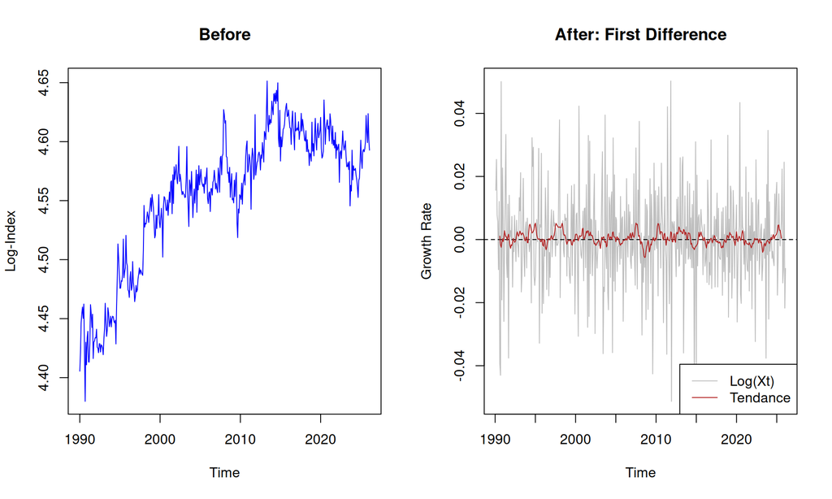

The visual inspection of the first-differenced series $W_t = \nabla \ln(X_t)$ confirms the effectiveness of the transformation. The series now exhibits a clear mean-reverting behavior, oscillating stably around a zero mean with no discernible trend. Furthermore, the variance appears to be relatively constant over time, despite minor volatility clusters. These observations provide strong visual evidence that the differentiated series is stationary, fulfilling the necessary condition for $ARMA$ identification.

## Part II : ARMA models

### a) Choix du modèle ARMA et estimation des paramètres

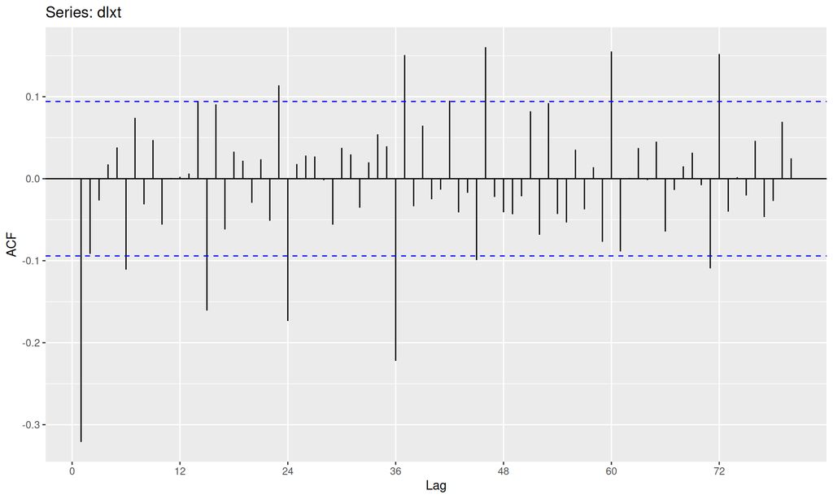

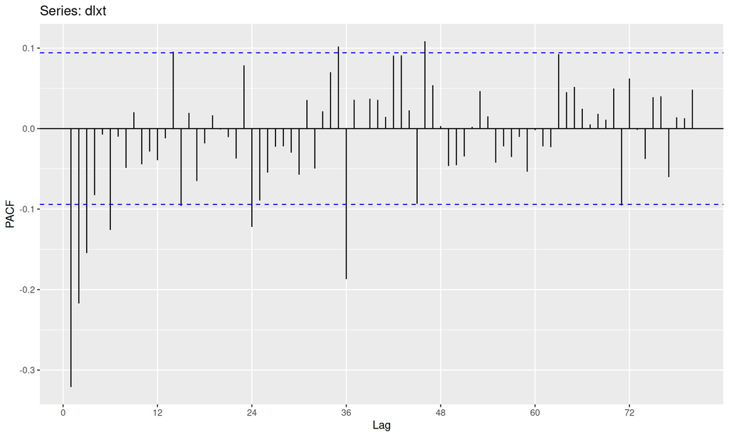

Simultaneously, the **PACF plot** displays significant coefficients for the first three lags before dropping sharply at lag 4. This truncation suggests that the internal memory of the series is effectively characterized by an autoregressive structure of order 3, setting the search limit at $p_{max} = 3$.

As a result, the model selection via grid search is restricted to the $ARIMA(p,1,q)$ family with the following constraints:

- **Autoregressive order (**$p$): $p \leq 3$
- **Moving average order (**$q$): $q \leq 1$

We are now going to test all these specifications, and select the model that has the lower information criteria AIC/BIC.

#### Estimation

```
             ma1    intercept
coef -0.52700881 0.0004157572
se    0.04973504 0.0003281620
pval  0.00000000 0.2051815646
```

```
               ar1    intercept
coef -3.213395e-01 0.0004294832
se    4.552435e-02 0.0005396221
pval  1.681544e-12 0.4260923763
```

```
             ar1         ma1    intercept
coef 0.265125328 -0.72374430 0.0004080013
se   0.085470632  0.06221298 0.0002605277
pval 0.001922527  0.00000000 0.1173352956
```

```
             ar1           ar2    intercept
coef -0.39455426 -2.229463e-01 0.0004268226
se    0.04703745  4.720658e-02 0.0004310892
pval  0.00000000  2.326429e-06 0.3221239462
```

```
            ar1         ar2           ma1    intercept
coef 0.25493531 -0.01175512 -7.122580e-01 0.0004080825
se   0.10680371  0.07217300  9.524378e-02 0.0002633327
pval 0.01698872  0.87061751  7.527312e-14 0.1212174122
```

```
             ar1           ar2           ar3   intercept
coef -0.43059077 -2.878290e-01 -0.1612343353 0.000418694
se    0.04765008  5.042398e-02  0.0478935512 0.000367282
pval  0.00000000  1.141919e-08  0.0007612458 0.254294863
```

```
            ar1          ar2        ar3           ma1    intercept
coef 0.27662137 -0.003056836 0.01397351 -7.338529e-01 0.0004081766
se   0.16085806  0.086963916 0.08059904  1.522701e-01 0.0002589717
pval 0.08549405  0.971959630 0.86236005  1.439787e-06 0.1149926597
```

Among all candidates, only ARMA(2,1) and ARMA(3,1) have coefficients that are non significant !

```
      lag       pval
 [1,]   1         NA
 [2,]   2 0.01923991
 [3,]   3 0.02704537
 [4,]   4 0.06276631
 [5,]   5 0.11878651
 [6,]   6 0.04626676
 [7,]   7 0.07208153
 [8,]   8 0.11309104
 [9,]   9 0.16149933
[10,]  10 0.16262493
[11,]  11 0.21664917
[12,]  12 0.28400317
[13,]  13 0.33534978
[14,]  14 0.33334951
[15,]  15 0.09467405
[16,]  16 0.12327869
[17,]  17 0.13849034
[18,]  18 0.17022506
[19,]  19 0.20676425
[20,]  20 0.24622864
[21,]  21 0.29813391
[22,]  22 0.30969804
[23,]  23 0.35813233
[24,]  24 0.02610903
```

```
      lag         pval
 [1,]   1           NA
 [2,]   2 2.108163e-07
 [3,]   3 6.673769e-07
 [4,]   4 2.564466e-06
 [5,]   5 8.600775e-06
 [6,]   6 4.154024e-06
 [7,]   7 8.291891e-06
 [8,]   8 2.100299e-05
 [9,]   9 4.314181e-05
[10,]  10 5.859966e-05
[11,]  11 1.161492e-04
[12,]  12 2.300255e-04
[13,]  13 3.260836e-04
[14,]  14 3.275934e-04
[15,]  15 3.457646e-05
[16,]  16 5.511510e-05
[17,]  17 8.602224e-05
[18,]  18 1.377217e-04
[19,]  19 2.106343e-04
[20,]  20 3.347336e-04
[21,]  21 5.508011e-04
[22,]  22 8.601670e-04
[23,]  23 8.211289e-04
[24,]  24 2.193941e-05
```

```
      lag       pval
 [1,]   1         NA
 [2,]   2         NA
 [3,]   3 0.85870393
 [4,]   4 0.82648338
 [5,]   5 0.88143519
 [6,]   6 0.42706123
 [7,]   7 0.45580563
 [8,]   8 0.55876731
 [9,]   9 0.64491986
[10,]  10 0.60035355
[11,]  11 0.68884112
[12,]  12 0.77119922
[13,]  13 0.83584883
[14,]  14 0.79900157
[15,]  15 0.25104511
[16,]  16 0.28164463
[17,]  17 0.26748070
[18,]  18 0.32420048
[19,]  19 0.38795996
[20,]  20 0.41291945
[21,]  21 0.47480993
[22,]  22 0.41842803
[23,]  23 0.45638880
[24,]  24 0.03019312
```

```
      lag         pval
 [1,]   1           NA
 [2,]   2           NA
 [3,]   3 0.0004364515
 [4,]   4 0.0018452793
 [5,]   5 0.0054063169
 [6,]   6 0.0024459590
 [7,]   7 0.0036434928
 [8,]   8 0.0071404362
 [9,]   9 0.0108631427
[10,]  10 0.0109792557
[11,]  11 0.0183907543
[12,]  12 0.0287788305
[13,]  13 0.0421802149
[14,]  14 0.0322894200
[15,]  15 0.0035954480
[16,]  16 0.0048634419
[17,]  17 0.0052152383
[18,]  18 0.0065684077
[19,]  19 0.0094227728
[20,]  20 0.0132670588
[21,]  21 0.0181266135
[22,]  22 0.0195827485
[23,]  23 0.0217878579
[24,]  24 0.0005087318
```

```
      lag        pval
 [1,]   1          NA
 [2,]   2          NA
 [3,]   3          NA
 [4,]   4 0.021460336
 [5,]   5 0.069620648
 [6,]   6 0.030632100
 [7,]   7 0.044108668
 [8,]   8 0.073764009
 [9,]   9 0.114456471
[10,]  10 0.124600128
[11,]  11 0.183331885
[12,]  12 0.252975059
[13,]  13 0.323528721
[14,]  14 0.279342903
[15,]  15 0.049840496
[16,]  16 0.058001376
[17,]  17 0.059121497
[18,]  18 0.077788073
[19,]  19 0.097598962
[20,]  20 0.127606136
[21,]  21 0.163700272
[22,]  22 0.147134005
[23,]  23 0.169066303
[24,]  24 0.007462776
```

```
[1] 3
```

```
[1] 3
```